# Risk Factor Analysis

## Outcome Variable

**Outcome Variable:** ever_stunted

## Predictor Variables

**Intervention Variable:** mwtkg

**Adjustment Set:**

- arm
- W_mage
- meducyrs
- feducyrs
- W_nchldlt5
- brthmon
- W_parity
- delta_W_mage
- delta_meducyrs
- delta_feducyrs
- delta_W_nchldlt5
- delta_brthmon
- delta_W_parity

## Stratifying Variables

The analysis was stratified on these variable(s):

- agecat
- studyid
- country

## Data Summary

| agecat | studyid | country | mwtkg | ever_stunted | n_cell | n |
| --- | --- | --- | --- | --- | --- | --- |
| 0-24 months | iLiNS-Zinc | BURKINA FASO | >=58 kg | 0 | 705 | 3216 |
| 0-24 months | iLiNS-Zinc | BURKINA FASO | >=58 kg | 1 | 232 | 3216 |
| 0-24 months | iLiNS-Zinc | BURKINA FASO | <52 kg | 0 | 658 | 3216 |
| 0-24 months | iLiNS-Zinc | BURKINA FASO | <52 kg | 1 | 543 | 3216 |
| 0-24 months | iLiNS-Zinc | BURKINA FASO | [52-58) kg | 0 | 706 | 3216 |
| 0-24 months | iLiNS-Zinc | BURKINA FASO | [52-58) kg | 1 | 372 | 3216 |
| 0-24 months | JiVitA-3 | BANGLADESH | >=58 kg | 0 | 405 | 27196 |
| 0-24 months | JiVitA-3 | BANGLADESH | >=58 kg | 1 | 264 | 27196 |
| 0-24 months | JiVitA-3 | BANGLADESH | <52 kg | 0 | 12291 | 27196 |
| 0-24 months | JiVitA-3 | BANGLADESH | <52 kg | 1 | 12462 | 27196 |
| 0-24 months | JiVitA-3 | BANGLADESH | [52-58) kg | 0 | 1028 | 27196 |
| 0-24 months | JiVitA-3 | BANGLADESH | [52-58) kg | 1 | 746 | 27196 |
| 0-24 months | LCNI-5 | MALAWI | >=58 kg | 0 | 55 | 838 |
| 0-24 months | LCNI-5 | MALAWI | >=58 kg | 1 | 59 | 838 |
| 0-24 months | LCNI-5 | MALAWI | <52 kg | 0 | 145 | 838 |
| 0-24 months | LCNI-5 | MALAWI | <52 kg | 1 | 359 | 838 |
| 0-24 months | LCNI-5 | MALAWI | [52-58) kg | 0 | 105 | 838 |
| 0-24 months | LCNI-5 | MALAWI | [52-58) kg | 1 | 115 | 838 |
| 0-24 months | MAL-ED | BANGLADESH | >=58 kg | 0 | 28 | 254 |
| 0-24 months | MAL-ED | BANGLADESH | >=58 kg | 1 | 20 | 254 |
| 0-24 months | MAL-ED | BANGLADESH | <52 kg | 0 | 49 | 254 |
| 0-24 months | MAL-ED | BANGLADESH | <52 kg | 1 | 113 | 254 |
| 0-24 months | MAL-ED | BANGLADESH | [52-58) kg | 0 | 21 | 254 |
| 0-24 months | MAL-ED | BANGLADESH | [52-58) kg | 1 | 23 | 254 |
| 0-24 months | MAL-ED | BRAZIL | >=58 kg | 0 | 106 | 221 |
| 0-24 months | MAL-ED | BRAZIL | >=58 kg | 1 | 37 | 221 |
| 0-24 months | MAL-ED | BRAZIL | <52 kg | 0 | 30 | 221 |
| 0-24 months | MAL-ED | BRAZIL | <52 kg | 1 | 12 | 221 |
| 0-24 months | MAL-ED | BRAZIL | [52-58) kg | 0 | 28 | 221 |
| 0-24 months | MAL-ED | BRAZIL | [52-58) kg | 1 | 8 | 221 |

[output cut: 270 more lines]

The following strata were considered:

- agecat: 0-24 months, studyid: iLiNS-Zinc, country: BURKINA FASO
- agecat: 0-24 months, studyid: JiVitA-3, country: BANGLADESH
- agecat: 0-24 months, studyid: LCNI-5, country: MALAWI
- agecat: 0-24 months, studyid: MAL-ED, country: BANGLADESH
- agecat: 0-24 months, studyid: MAL-ED, country: BRAZIL
- agecat: 0-24 months, studyid: MAL-ED, country: INDIA
- agecat: 0-24 months, studyid: MAL-ED, country: NEPAL
- agecat: 0-24 months, studyid: MAL-ED, country: PERU
- agecat: 0-24 months, studyid: MAL-ED, country: SOUTH AFRICA
- agecat: 0-24 months, studyid: MAL-ED, country: TANZANIA, UNITED REPUBLIC OF
- agecat: 0-24 months, studyid: NIH-Birth, country: BANGLADESH
- agecat: 0-24 months, studyid: NIH-Crypto, country: BANGLADESH
- agecat: 0-24 months, studyid: PROBIT, country: BELARUS
- agecat: 0-24 months, studyid: PROVIDE, country: BANGLADESH
- agecat: 0-24 months, studyid: SAS-CompFeed, country: INDIA
- agecat: 0-24 months, studyid: TanzaniaChild2, country: TANZANIA, UNITED REPUBLIC OF
- agecat: 0-24 months, studyid: ZVITAMBO, country: ZIMBABWE
- agecat: 0-6 months, studyid: JiVitA-3, country: BANGLADESH
- agecat: 0-6 months, studyid: LCNI-5, country: MALAWI
- agecat: 0-6 months, studyid: MAL-ED, country: BANGLADESH
- agecat: 0-6 months, studyid: MAL-ED, country: BRAZIL
- agecat: 0-6 months, studyid: MAL-ED, country: INDIA
- agecat: 0-6 months, studyid: MAL-ED, country: NEPAL
- agecat: 0-6 months, studyid: MAL-ED, country: PERU
- agecat: 0-6 months, studyid: MAL-ED, country: SOUTH AFRICA
- agecat: 0-6 months, studyid: MAL-ED, country: TANZANIA, UNITED REPUBLIC OF
- agecat: 0-6 months, studyid: NIH-Birth, country: BANGLADESH
- agecat: 0-6 months, studyid: NIH-Crypto, country: BANGLADESH
- agecat: 0-6 months, studyid: PROBIT, country: BELARUS
- agecat: 0-6 months, studyid: PROVIDE, country: BANGLADESH
- agecat: 0-6 months, studyid: SAS-CompFeed, country: INDIA
- agecat: 0-6 months, studyid: TanzaniaChild2, country: TANZANIA, UNITED REPUBLIC OF
- agecat: 0-6 months, studyid: ZVITAMBO, country: ZIMBABWE
- agecat: 6-24 months, studyid: iLiNS-Zinc, country: BURKINA FASO
- agecat: 6-24 months, studyid: JiVitA-3, country: BANGLADESH
- agecat: 6-24 months, studyid: LCNI-5, country: MALAWI
- agecat: 6-24 months, studyid: MAL-ED, country: BANGLADESH
- agecat: 6-24 months, studyid: MAL-ED, country: BRAZIL
- agecat: 6-24 months, studyid: MAL-ED, country: INDIA
- agecat: 6-24 months, studyid: MAL-ED, country: NEPAL
- agecat: 6-24 months, studyid: MAL-ED, country: PERU
- agecat: 6-24 months, studyid: MAL-ED, country: SOUTH AFRICA
- agecat: 6-24 months, studyid: MAL-ED, country: TANZANIA, UNITED REPUBLIC OF
- agecat: 6-24 months, studyid: NIH-Birth, country: BANGLADESH
- agecat: 6-24 months, studyid: NIH-Crypto, country: BANGLADESH
- agecat: 6-24 months, studyid: PROBIT, country: BELARUS
- agecat: 6-24 months, studyid: PROVIDE, country: BANGLADESH
- agecat: 6-24 months, studyid: SAS-CompFeed, country: INDIA
- agecat: 6-24 months, studyid: TanzaniaChild2, country: TANZANIA, UNITED REPUBLIC OF
- agecat: 6-24 months, studyid: ZVITAMBO, country: ZIMBABWE

### Dropped Strata

Some strata were dropped due to rare outcomes:

- agecat: 6-24 months, studyid: MAL-ED, country: BRAZIL

## Methods Detail

We’re interested in the causal parameters $E[Y_a]$ for all values of $a \in \mathcal{A}$. These parameters represent the mean outcome if, possibly contrary to fact, we intervened to set all units to have $A=a$. Under the randomization and positivity assumptions, these are identified by the statistical parameters $\psi_a=E_W[E_{Y|A,W}(Y|A=a,W)]$. In addition, we’re interested in the mean of $Y$, $E[Y]$ under no intervention (the observed mean). We will estimate these parameters by using SuperLearner to fit the relevant likelihood factors – $E_{Y|A,W}(Y|A=a,W)$ and $p(A=a|W)$, and then updating our likelihood fit using a joint TMLE.

For unadjusted analyses ($W=\{\}$), initial likelihoods were estimated using Lrnr_glm to estimate the simple $E(Y|A)$ and Lrnr_mean to estimate $p(A)$. For adjusted analyses, a small library containing Lrnr_glmnet, Lrnr_xgboost, and Lrnr_mean was used.

Having estimated these parameters, we will then use the delta method to estimate relative risks and attributable risks relative to a prespecified baseline level of $A$.

# Results Detail

## Results Plots

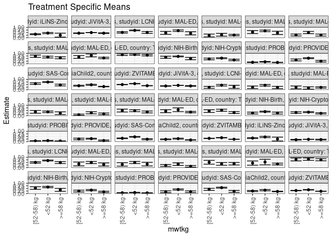

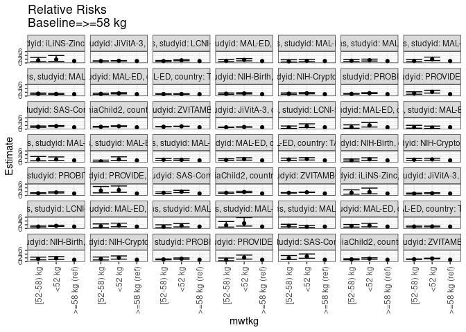

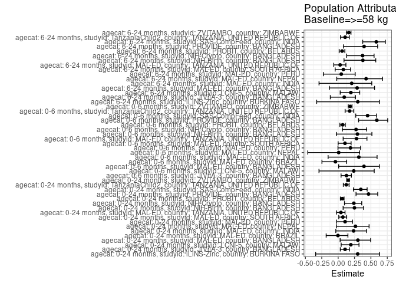

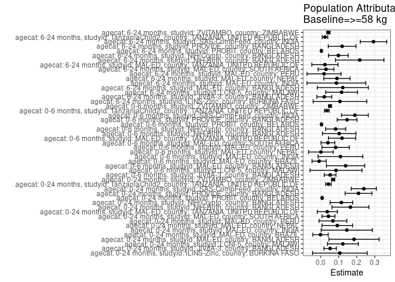

## Results Table

### Parameter: TSM

| agecat | studyid | country | intervention_level | baseline_level | estimate | ci_lower | ci_upper |
| --- | --- | --- | --- | --- | --- | --- | --- |
| 0-24 months | iLiNS-Zinc | BURKINA FASO | >=58 kg | NA | 0.2502536 | 0.0600179 | 0.4404894 |
| 0-24 months | iLiNS-Zinc | BURKINA FASO | <52 kg | NA | 0.4519554 | 0.3928135 | 0.5110973 |
| 0-24 months | iLiNS-Zinc | BURKINA FASO | [52-58) kg | NA | 0.3416436 | 0.2983870 | 0.3849002 |
| 0-24 months | JiVitA-3 | BANGLADESH | >=58 kg | NA | 0.4431024 | 0.4079260 | 0.4782788 |
| 0-24 months | JiVitA-3 | BANGLADESH | <52 kg | NA | 0.5012051 | 0.4931216 | 0.5092885 |
| 0-24 months | JiVitA-3 | BANGLADESH | [52-58) kg | NA | 0.4400744 | 0.4154141 | 0.4647347 |
| 0-24 months | LCNI-5 | MALAWI | >=58 kg | NA | 0.5129193 | 0.4202459 | 0.6055927 |
| 0-24 months | LCNI-5 | MALAWI | <52 kg | NA | 0.7123099 | 0.6727542 | 0.7518656 |
| 0-24 months | LCNI-5 | MALAWI | [52-58) kg | NA | 0.5152325 | 0.4482140 | 0.5822510 |
| 0-24 months | MAL-ED | BANGLADESH | >=58 kg | NA | 0.4290887 | 0.2765877 | 0.5815897 |
| 0-24 months | MAL-ED | BANGLADESH | <52 kg | NA | 0.6866032 | 0.6130708 | 0.7601357 |
| 0-24 months | MAL-ED | BANGLADESH | [52-58) kg | NA | 0.4713727 | 0.3282643 | 0.6144811 |
| 0-24 months | MAL-ED | BRAZIL | >=58 kg | NA | 0.2587413 | 0.1867992 | 0.3306833 |
| 0-24 months | MAL-ED | BRAZIL | <52 kg | NA | 0.2857143 | 0.1487806 | 0.4226479 |
| 0-24 months | MAL-ED | BRAZIL | [52-58) kg | NA | 0.2222222 | 0.0861081 | 0.3583363 |
| 0-24 months | MAL-ED | INDIA | >=58 kg | NA | 0.4706870 | 0.3146753 | 0.6266987 |
| 0-24 months | MAL-ED | INDIA | <52 kg | NA | 0.6685966 | 0.5932130 | 0.7439801 |
| 0-24 months | MAL-ED | INDIA | [52-58) kg | NA | 0.5493421 | 0.4050707 | 0.6936135 |
| 0-24 months | MAL-ED | NEPAL | >=58 kg | NA | 0.2565011 | 0.1556207 | 0.3573816 |
| 0-24 months | MAL-ED | NEPAL | <52 kg | NA | 0.5048333 | 0.3937368 | 0.6159298 |
| 0-24 months | MAL-ED | NEPAL | [52-58) kg | NA | 0.2659019 | 0.1704531 | 0.3613507 |
| 0-24 months | MAL-ED | PERU | >=58 kg | NA | 0.5734053 | 0.4777995 | 0.6690112 |
| 0-24 months | MAL-ED | PERU | <52 kg | NA | 0.6451227 | 0.5568072 | 0.7334381 |
| 0-24 months | MAL-ED | PERU | [52-58) kg | NA | 0.7260480 | 0.6115775 | 0.8405184 |
| 0-24 months | MAL-ED | SOUTH AFRICA | >=58 kg | NA | 0.5567010 | 0.4866665 | 0.6267356 |
| 0-24 months | MAL-ED | SOUTH AFRICA | <52 kg | NA | 0.8000000 | 0.6565987 | 0.9434013 |
| 0-24 months | MAL-ED | SOUTH AFRICA | [52-58) kg | NA | 0.6521739 | 0.5142823 | 0.7900655 |
| 0-24 months | MAL-ED | TANZANIA, UNITED REPUBLIC OF | >=58 kg | NA | 0.8265306 | 0.7514158 | 0.9016455 |
| 0-24 months | MAL-ED | TANZANIA, UNITED REPUBLIC OF | <52 kg | NA | 0.8888889 | 0.8268616 | 0.9509162 |
| 0-24 months | MAL-ED | TANZANIA, UNITED REPUBLIC OF | [52-58) kg | NA | 0.8813559 | 0.7986816 | 0.9640303 |

[output cut: 117 more lines]

### Parameter: E(Y)

| agecat | studyid | country | intervention_level | baseline_level | estimate | ci_lower | ci_upper |
| --- | --- | --- | --- | --- | --- | --- | --- |
| 0-24 months | iLiNS-Zinc | BURKINA FASO | NA | NA | 0.3566542 | 0.3069876 | 0.4063208 |
| 0-24 months | JiVitA-3 | BANGLADESH | NA | NA | 0.4953670 | 0.4875503 | 0.5031837 |
| 0-24 months | LCNI-5 | MALAWI | NA | NA | 0.6360382 | 0.6034429 | 0.6686335 |
| 0-24 months | MAL-ED | BANGLADESH | NA | NA | 0.6141732 | 0.5541901 | 0.6741564 |
| 0-24 months | MAL-ED | BRAZIL | NA | NA | 0.2579186 | 0.2001084 | 0.3157287 |
| 0-24 months | MAL-ED | INDIA | NA | NA | 0.6157025 | 0.5542897 | 0.6771153 |
| 0-24 months | MAL-ED | NEPAL | NA | NA | 0.3487395 | 0.2880656 | 0.4094134 |
| 0-24 months | MAL-ED | PERU | NA | NA | 0.6413793 | 0.5860858 | 0.6966728 |
| 0-24 months | MAL-ED | SOUTH AFRICA | NA | NA | 0.6000000 | 0.5414566 | 0.6585434 |
| 0-24 months | MAL-ED | TANZANIA, UNITED REPUBLIC OF | NA | NA | 0.8632812 | 0.8211147 | 0.9054478 |
| 0-24 months | NIH-Birth | BANGLADESH | NA | NA | 0.6645469 | 0.6276196 | 0.7014742 |
| 0-24 months | NIH-Crypto | BANGLADESH | NA | NA | 0.4794702 | 0.4438115 | 0.5151289 |
| 0-24 months | PROBIT | BELARUS | NA | NA | 0.1289573 | 0.1128390 | 0.1450756 |
| 0-24 months | PROVIDE | BANGLADESH | NA | NA | 0.4529148 | 0.4151667 | 0.4906629 |
| 0-24 months | SAS-CompFeed | INDIA | NA | NA | 0.6910891 | 0.6503148 | 0.7318634 |
| 0-24 months | TanzaniaChild2 | TANZANIA, UNITED REPUBLIC OF | NA | NA | 0.3465136 | 0.3272783 | 0.3657490 |
| 0-24 months | ZVITAMBO | ZIMBABWE | NA | NA | 0.4563549 | 0.4471315 | 0.4655783 |
| 0-6 months | JiVitA-3 | BANGLADESH | NA | NA | 0.4129746 | 0.4055418 | 0.4204074 |
| 0-6 months | LCNI-5 | MALAWI | NA | NA | 0.3579336 | 0.3007518 | 0.4151153 |
| 0-6 months | MAL-ED | BANGLADESH | NA | NA | 0.3503937 | 0.2916054 | 0.4091820 |
| 0-6 months | MAL-ED | BRAZIL | NA | NA | 0.2081448 | 0.1544982 | 0.2617914 |
| 0-6 months | MAL-ED | INDIA | NA | NA | 0.3471074 | 0.2870050 | 0.4072099 |
| 0-6 months | MAL-ED | NEPAL | NA | NA | 0.1764706 | 0.1279362 | 0.2250050 |
| 0-6 months | MAL-ED | PERU | NA | NA | 0.4413793 | 0.3841309 | 0.4986278 |
| 0-6 months | MAL-ED | SOUTH AFRICA | NA | NA | 0.3851852 | 0.3270313 | 0.4433391 |
| 0-6 months | MAL-ED | TANZANIA, UNITED REPUBLIC OF | NA | NA | 0.4218750 | 0.3612599 | 0.4824901 |
| 0-6 months | NIH-Birth | BANGLADESH | NA | NA | 0.3497615 | 0.3124631 | 0.3870600 |
| 0-6 months | NIH-Crypto | BANGLADESH | NA | NA | 0.3033113 | 0.2704998 | 0.3361228 |
| 0-6 months | PROBIT | BELARUS | NA | NA | 0.0659309 | 0.0552270 | 0.0766347 |
| 0-6 months | PROVIDE | BANGLADESH | NA | NA | 0.2481315 | 0.2153770 | 0.2808861 |
| 0-6 months | SAS-CompFeed | INDIA | NA | NA | 0.4226190 | 0.3935114 | 0.4517267 |
| 0-6 months | TanzaniaChild2 | TANZANIA, UNITED REPUBLIC OF | NA | NA | 0.1943027 | 0.1783091 | 0.2102964 |
| 0-6 months | ZVITAMBO | ZIMBABWE | NA | NA | 0.2824844 | 0.2741425 | 0.2908263 |
| 6-24 months | iLiNS-Zinc | BURKINA FASO | NA | NA | 0.3566542 | 0.3069876 | 0.4063208 |
| 6-24 months | JiVitA-3 | BANGLADESH | NA | NA | 0.2162884 | 0.2069101 | 0.2256667 |
| 6-24 months | LCNI-5 | MALAWI | NA | NA | 0.5989011 | 0.5632737 | 0.6345285 |
| 6-24 months | MAL-ED | BANGLADESH | NA | NA | 0.4240506 | 0.3467471 | 0.5013542 |
| 6-24 months | MAL-ED | INDIA | NA | NA | 0.4220779 | 0.3438191 | 0.5003367 |
| 6-24 months | MAL-ED | NEPAL | NA | NA | 0.2113402 | 0.1537425 | 0.2689379 |
| 6-24 months | MAL-ED | PERU | NA | NA | 0.3918919 | 0.3129763 | 0.4708075 |
| 6-24 months | MAL-ED | SOUTH AFRICA | NA | NA | 0.3741935 | 0.2977649 | 0.4506221 |
| 6-24 months | MAL-ED | TANZANIA, UNITED REPUBLIC OF | NA | NA | 0.7847222 | 0.7173567 | 0.8520877 |
| 6-24 months | NIH-Birth | BANGLADESH | NA | NA | 0.5739130 | 0.5216565 | 0.6261696 |
| 6-24 months | NIH-Crypto | BANGLADESH | NA | NA | 0.2628458 | 0.2244546 | 0.3012371 |
| 6-24 months | PROBIT | BELARUS | NA | NA | 0.0675171 | 0.0551317 | 0.0799025 |
| 6-24 months | PROVIDE | BANGLADESH | NA | NA | 0.3004386 | 0.2583143 | 0.3425629 |
| 6-24 months | SAS-CompFeed | INDIA | NA | NA | 0.5030826 | 0.4587775 | 0.5473878 |
| 6-24 months | TanzaniaChild2 | TANZANIA, UNITED REPUBLIC OF | NA | NA | 0.2277354 | 0.2069978 | 0.2484730 |
| 6-24 months | ZVITAMBO | ZIMBABWE | NA | NA | 0.2645703 | 0.2545045 | 0.2746362 |

### Parameter: RR

| agecat | studyid | country | intervention_level | baseline_level | estimate | ci_lower | ci_upper |
| --- | --- | --- | --- | --- | --- | --- | --- |
| 0-24 months | iLiNS-Zinc | BURKINA FASO | >=58 kg | >=58 kg | 1.0000000 | 1.0000000 | 1.000000 |
| 0-24 months | iLiNS-Zinc | BURKINA FASO | <52 kg | >=58 kg | 1.8059894 | 0.8317719 | 3.921265 |
| 0-24 months | iLiNS-Zinc | BURKINA FASO | [52-58) kg | >=58 kg | 1.3651894 | 0.6299828 | 2.958401 |
| 0-24 months | JiVitA-3 | BANGLADESH | >=58 kg | >=58 kg | 1.0000000 | 1.0000000 | 1.000000 |
| 0-24 months | JiVitA-3 | BANGLADESH | <52 kg | >=58 kg | 1.1311270 | 1.0440441 | 1.225474 |
| 0-24 months | JiVitA-3 | BANGLADESH | [52-58) kg | >=58 kg | 0.9931665 | 0.9031130 | 1.092200 |
| 0-24 months | LCNI-5 | MALAWI | >=58 kg | >=58 kg | 1.0000000 | 1.0000000 | 1.000000 |
| 0-24 months | LCNI-5 | MALAWI | <52 kg | >=58 kg | 1.3887367 | 1.1495205 | 1.677734 |
| 0-24 months | LCNI-5 | MALAWI | [52-58) kg | >=58 kg | 1.0045099 | 0.8038763 | 1.255218 |
| 0-24 months | MAL-ED | BANGLADESH | >=58 kg | >=58 kg | 1.0000000 | 1.0000000 | 1.000000 |
| 0-24 months | MAL-ED | BANGLADESH | <52 kg | >=58 kg | 1.6001428 | 1.1023706 | 2.322682 |
| 0-24 months | MAL-ED | BANGLADESH | [52-58) kg | >=58 kg | 1.0985437 | 0.6887784 | 1.752085 |
| 0-24 months | MAL-ED | BRAZIL | >=58 kg | >=58 kg | 1.0000000 | 1.0000000 | 1.000000 |
| 0-24 months | MAL-ED | BRAZIL | <52 kg | >=58 kg | 1.1042471 | 0.6344996 | 1.921769 |
| 0-24 months | MAL-ED | BRAZIL | [52-58) kg | >=58 kg | 0.8588589 | 0.4383144 | 1.682898 |
| 0-24 months | MAL-ED | INDIA | >=58 kg | >=58 kg | 1.0000000 | 1.0000000 | 1.000000 |
| 0-24 months | MAL-ED | INDIA | <52 kg | >=58 kg | 1.4204696 | 0.9997251 | 2.018289 |
| 0-24 months | MAL-ED | INDIA | [52-58) kg | >=58 kg | 1.1671071 | 0.7629608 | 1.785333 |
| 0-24 months | MAL-ED | NEPAL | >=58 kg | >=58 kg | 1.0000000 | 1.0000000 | 1.000000 |
| 0-24 months | MAL-ED | NEPAL | <52 kg | >=58 kg | 1.9681523 | 1.2537241 | 3.089694 |
| 0-24 months | MAL-ED | NEPAL | [52-58) kg | >=58 kg | 1.0366500 | 0.6087271 | 1.765394 |
| 0-24 months | MAL-ED | PERU | >=58 kg | >=58 kg | 1.0000000 | 1.0000000 | 1.000000 |
| 0-24 months | MAL-ED | PERU | <52 kg | >=58 kg | 1.1250727 | 0.9066465 | 1.396121 |
| 0-24 months | MAL-ED | PERU | [52-58) kg | >=58 kg | 1.2662037 | 1.0063216 | 1.593200 |
| 0-24 months | MAL-ED | SOUTH AFRICA | >=58 kg | >=58 kg | 1.0000000 | 1.0000000 | 1.000000 |
| 0-24 months | MAL-ED | SOUTH AFRICA | <52 kg | >=58 kg | 1.4370370 | 1.1544123 | 1.788854 |
| 0-24 months | MAL-ED | SOUTH AFRICA | [52-58) kg | >=58 kg | 1.1714976 | 0.9159929 | 1.498272 |
| 0-24 months | MAL-ED | TANZANIA, UNITED REPUBLIC OF | >=58 kg | >=58 kg | 1.0000000 | 1.0000000 | 1.000000 |
| 0-24 months | MAL-ED | TANZANIA, UNITED REPUBLIC OF | <52 kg | >=58 kg | 1.0754458 | 0.9590191 | 1.206007 |
| 0-24 months | MAL-ED | TANZANIA, UNITED REPUBLIC OF | [52-58) kg | >=58 kg | 1.0663319 | 0.9357728 | 1.215107 |

[output cut: 117 more lines]

### Parameter: PAR

| agecat | studyid | country | intervention_level | baseline_level | estimate | ci_lower | ci_upper |
| --- | --- | --- | --- | --- | --- | --- | --- |
| 0-24 months | iLiNS-Zinc | BURKINA FASO | >=58 kg | NA | 0.1064006 | -0.0453176 | 0.2581188 |
| 0-24 months | JiVitA-3 | BANGLADESH | >=58 kg | NA | 0.0522646 | 0.0176298 | 0.0868993 |
| 0-24 months | LCNI-5 | MALAWI | >=58 kg | NA | 0.1231189 | 0.0373857 | 0.2088521 |
| 0-24 months | MAL-ED | BANGLADESH | >=58 kg | NA | 0.1850845 | 0.0459412 | 0.3242278 |
| 0-24 months | MAL-ED | BRAZIL | >=58 kg | NA | -0.0008227 | -0.0434813 | 0.0418359 |
| 0-24 months | MAL-ED | INDIA | >=58 kg | NA | 0.1450155 | 0.0031681 | 0.2868629 |
| 0-24 months | MAL-ED | NEPAL | >=58 kg | NA | 0.0922384 | 0.0075537 | 0.1769230 |
| 0-24 months | MAL-ED | PERU | >=58 kg | NA | 0.0679740 | -0.0091450 | 0.1450929 |
| 0-24 months | MAL-ED | SOUTH AFRICA | >=58 kg | NA | 0.0432990 | 0.0074698 | 0.0791281 |
| 0-24 months | MAL-ED | TANZANIA, UNITED REPUBLIC OF | >=58 kg | NA | 0.0367506 | -0.0189308 | 0.0924320 |
| 0-24 months | NIH-Birth | BANGLADESH | >=58 kg | NA | 0.1651973 | 0.0627581 | 0.2676366 |
| 0-24 months | NIH-Crypto | BANGLADESH | >=58 kg | NA | 0.1149097 | 0.0523321 | 0.1774873 |
| 0-24 months | PROBIT | BELARUS | >=58 kg | NA | 0.0080888 | 0.0047145 | 0.0114630 |
| 0-24 months | PROVIDE | BANGLADESH | >=58 kg | NA | 0.2100404 | 0.1358963 | 0.2841845 |
| 0-24 months | SAS-CompFeed | INDIA | >=58 kg | NA | 0.2391644 | 0.1693339 | 0.3089950 |
| 0-24 months | TanzaniaChild2 | TANZANIA, UNITED REPUBLIC OF | >=58 kg | NA | 0.0430304 | 0.0277010 | 0.0583598 |
| 0-24 months | ZVITAMBO | ZIMBABWE | >=58 kg | NA | 0.0693712 | 0.0603569 | 0.0783856 |
| 0-6 months | JiVitA-3 | BANGLADESH | >=58 kg | NA | 0.0524093 | 0.0198554 | 0.0849633 |
| 0-6 months | LCNI-5 | MALAWI | >=58 kg | NA | 0.0852063 | -0.0590172 | 0.2294298 |
| 0-6 months | MAL-ED | BANGLADESH | >=58 kg | NA | 0.1382036 | 0.0322202 | 0.2441870 |
| 0-6 months | MAL-ED | BRAZIL | >=58 kg | NA | -0.0086384 | -0.0477583 | 0.0304815 |
| 0-6 months | MAL-ED | INDIA | >=58 kg | NA | 0.1097163 | -0.0145545 | 0.2339871 |
| 0-6 months | MAL-ED | NEPAL | >=58 kg | NA | 0.0014706 | -0.0666265 | 0.0695677 |
| 0-6 months | MAL-ED | PERU | >=58 kg | NA | 0.0831491 | 0.0072759 | 0.1590224 |
| 0-6 months | MAL-ED | SOUTH AFRICA | >=58 kg | NA | 0.0401447 | 0.0021310 | 0.0781584 |
| 0-6 months | MAL-ED | TANZANIA, UNITED REPUBLIC OF | >=58 kg | NA | 0.1184411 | 0.0427909 | 0.1940913 |
| 0-6 months | NIH-Birth | BANGLADESH | >=58 kg | NA | 0.1028719 | 0.0101051 | 0.1956386 |
| 0-6 months | NIH-Crypto | BANGLADESH | >=58 kg | NA | 0.0829796 | 0.0270573 | 0.1389019 |
| 0-6 months | PROBIT | BELARUS | >=58 kg | NA | 0.0045306 | 0.0018124 | 0.0072487 |
| 0-6 months | PROVIDE | BANGLADESH | >=58 kg | NA | 0.1466027 | 0.0915852 | 0.2016202 |
| 0-6 months | SAS-CompFeed | INDIA | >=58 kg | NA | 0.1897839 | 0.1155370 | 0.2640307 |
| 0-6 months | TanzaniaChild2 | TANZANIA, UNITED REPUBLIC OF | >=58 kg | NA | 0.0340632 | 0.0209899 | 0.0471365 |
| 0-6 months | ZVITAMBO | ZIMBABWE | >=58 kg | NA | 0.0518484 | 0.0436627 | 0.0600341 |
| 6-24 months | iLiNS-Zinc | BURKINA FASO | >=58 kg | NA | 0.1069145 | -0.0420261 | 0.2558552 |
| 6-24 months | JiVitA-3 | BANGLADESH | >=58 kg | NA | 0.0200958 | -0.0212639 | 0.0614554 |
| 6-24 months | LCNI-5 | MALAWI | >=58 kg | NA | 0.1162435 | 0.0278048 | 0.2046823 |
| 6-24 months | MAL-ED | BANGLADESH | >=58 kg | NA | 0.1228335 | -0.0184029 | 0.2640700 |
| 6-24 months | MAL-ED | INDIA | >=58 kg | NA | 0.0873659 | -0.0756952 | 0.2504271 |
| 6-24 months | MAL-ED | NEPAL | >=58 kg | NA | 0.0901281 | 0.0172641 | 0.1629921 |
| 6-24 months | MAL-ED | PERU | >=58 kg | NA | 0.0186591 | -0.0755971 | 0.1129154 |
| 6-24 months | MAL-ED | SOUTH AFRICA | >=58 kg | NA | 0.0296557 | -0.0140735 | 0.0733850 |
| 6-24 months | MAL-ED | TANZANIA, UNITED REPUBLIC OF | >=58 kg | NA | 0.0235282 | -0.0490455 | 0.0961019 |
| 6-24 months | NIH-Birth | BANGLADESH | >=58 kg | NA | 0.2165654 | 0.0820127 | 0.3511181 |
| 6-24 months | NIH-Crypto | BANGLADESH | >=58 kg | NA | 0.0981321 | 0.0434031 | 0.1528612 |
| 6-24 months | PROBIT | BELARUS | >=58 kg | NA | 0.0040671 | 0.0013752 | 0.0067589 |
| 6-24 months | PROVIDE | BANGLADESH | >=58 kg | NA | 0.1189877 | 0.0420614 | 0.1959140 |
| 6-24 months | SAS-CompFeed | INDIA | >=58 kg | NA | 0.2929306 | 0.2195259 | 0.3663354 |
| 6-24 months | TanzaniaChild2 | TANZANIA, UNITED REPUBLIC OF | >=58 kg | NA | 0.0241715 | 0.0087905 | 0.0395524 |
| 6-24 months | ZVITAMBO | ZIMBABWE | >=58 kg | NA | 0.0428947 | 0.0336411 | 0.0521482 |

### Parameter: PAF

| agecat | studyid | country | intervention_level | baseline_level | estimate | ci_lower | ci_upper |
| --- | --- | --- | --- | --- | --- | --- | --- |
| 0-24 months | iLiNS-Zinc | BURKINA FASO | >=58 kg | NA | 0.2983298 | -0.3436084 | 0.6335680 |
| 0-24 months | JiVitA-3 | BANGLADESH | >=58 kg | NA | 0.1055068 | 0.0328403 | 0.1727136 |
| 0-24 months | LCNI-5 | MALAWI | >=58 kg | NA | 0.1935715 | 0.0460607 | 0.3182723 |
| 0-24 months | MAL-ED | BANGLADESH | >=58 kg | NA | 0.3013556 | 0.0303963 | 0.4965943 |
| 0-24 months | MAL-ED | BRAZIL | >=58 kg | NA | -0.0031898 | -0.1830006 | 0.1492905 |
| 0-24 months | MAL-ED | INDIA | >=58 kg | NA | 0.2355285 | -0.0357634 | 0.4357624 |
| 0-24 months | MAL-ED | NEPAL | >=58 kg | NA | 0.2644907 | -0.0250780 | 0.4722608 |
| 0-24 months | MAL-ED | PERU | >=58 kg | NA | 0.1059809 | -0.0232815 | 0.2189147 |
| 0-24 months | MAL-ED | SOUTH AFRICA | >=58 kg | NA | 0.0721649 | 0.0097011 | 0.1306889 |
| 0-24 months | MAL-ED | TANZANIA, UNITED REPUBLIC OF | >=58 kg | NA | 0.0425709 | -0.0245477 | 0.1052924 |
| 0-24 months | NIH-Birth | BANGLADESH | >=58 kg | NA | 0.2485864 | 0.0760045 | 0.3889339 |
| 0-24 months | NIH-Crypto | BANGLADESH | >=58 kg | NA | 0.2396597 | 0.0968525 | 0.3598860 |
| 0-24 months | PROBIT | BELARUS | >=58 kg | NA | 0.0627243 | 0.0342023 | 0.0904040 |
| 0-24 months | PROVIDE | BANGLADESH | >=58 kg | NA | 0.4637525 | 0.2729615 | 0.6044758 |
| 0-24 months | SAS-CompFeed | INDIA | >=58 kg | NA | 0.3460689 | 0.2329430 | 0.4425109 |
| 0-24 months | TanzaniaChild2 | TANZANIA, UNITED REPUBLIC OF | >=58 kg | NA | 0.1241809 | 0.0788562 | 0.1672755 |
| 0-24 months | ZVITAMBO | ZIMBABWE | >=58 kg | NA | 0.1520115 | 0.1319236 | 0.1716346 |
| 0-6 months | JiVitA-3 | BANGLADESH | >=58 kg | NA | 0.1269069 | 0.0444959 | 0.2022102 |
| 0-6 months | LCNI-5 | MALAWI | >=58 kg | NA | 0.2380506 | -0.2925147 | 0.5508238 |
| 0-6 months | MAL-ED | BANGLADESH | >=58 kg | NA | 0.3944238 | 0.0080065 | 0.6303177 |
| 0-6 months | MAL-ED | BRAZIL | >=58 kg | NA | -0.0415020 | -0.2473085 | 0.1303464 |
| 0-6 months | MAL-ED | INDIA | >=58 kg | NA | 0.3160875 | -0.1534405 | 0.5944860 |
| 0-6 months | MAL-ED | NEPAL | >=58 kg | NA | 0.0083333 | -0.4633876 | 0.3279957 |
| 0-6 months | MAL-ED | PERU | >=58 kg | NA | 0.1883847 | -0.0027319 | 0.3430752 |
| 0-6 months | MAL-ED | SOUTH AFRICA | >=58 kg | NA | 0.1042219 | -0.0002223 | 0.1977599 |
| 0-6 months | MAL-ED | TANZANIA, UNITED REPUBLIC OF | >=58 kg | NA | 0.2807493 | 0.0764166 | 0.4398757 |
| 0-6 months | NIH-Birth | BANGLADESH | >=58 kg | NA | 0.2941200 | -0.0279867 | 0.5152987 |
| 0-6 months | NIH-Crypto | BANGLADESH | >=58 kg | NA | 0.2735790 | 0.0650625 | 0.4355907 |
| 0-6 months | PROBIT | BELARUS | >=58 kg | NA | 0.0687167 | 0.0267641 | 0.1088609 |
| 0-6 months | PROVIDE | BANGLADESH | >=58 kg | NA | 0.5908264 | 0.3122782 | 0.7565542 |
| 0-6 months | SAS-CompFeed | INDIA | >=58 kg | NA | 0.4490660 | 0.2689735 | 0.5847917 |
| 0-6 months | TanzaniaChild2 | TANZANIA, UNITED REPUBLIC OF | >=58 kg | NA | 0.1753100 | 0.1062747 | 0.2390127 |
| 0-6 months | ZVITAMBO | ZIMBABWE | >=58 kg | NA | 0.1835442 | 0.1542402 | 0.2118328 |
| 6-24 months | iLiNS-Zinc | BURKINA FASO | >=58 kg | NA | 0.2997708 | -0.3277468 | 0.6307120 |
| 6-24 months | JiVitA-3 | BANGLADESH | >=58 kg | NA | 0.0929118 | -0.1196367 | 0.2651108 |
| 6-24 months | LCNI-5 | MALAWI | >=58 kg | NA | 0.1940947 | 0.0313000 | 0.3295309 |
| 6-24 months | MAL-ED | BANGLADESH | >=58 kg | NA | 0.2896671 | -0.1352566 | 0.5555430 |
| 6-24 months | MAL-ED | INDIA | >=58 kg | NA | 0.2069900 | -0.2919332 | 0.5132373 |
| 6-24 months | MAL-ED | NEPAL | >=58 kg | NA | 0.4264597 | -0.0212821 | 0.6779064 |
| 6-24 months | MAL-ED | PERU | >=58 kg | NA | 0.0476130 | -0.2261037 | 0.2602248 |
| 6-24 months | MAL-ED | SOUTH AFRICA | >=58 kg | NA | 0.0792524 | -0.0454791 | 0.1891027 |
| 6-24 months | MAL-ED | TANZANIA, UNITED REPUBLIC OF | >=58 kg | NA | 0.0299828 | -0.0672917 | 0.1183916 |
| 6-24 months | NIH-Birth | BANGLADESH | >=58 kg | NA | 0.3773489 | 0.0893247 | 0.5742781 |
| 6-24 months | NIH-Crypto | BANGLADESH | >=58 kg | NA | 0.3733448 | 0.1302401 | 0.5484999 |
| 6-24 months | PROBIT | BELARUS | >=58 kg | NA | 0.0602376 | 0.0156685 | 0.1027887 |
| 6-24 months | PROVIDE | BANGLADESH | >=58 kg | NA | 0.3960467 | 0.0815585 | 0.6028493 |
| 6-24 months | SAS-CompFeed | INDIA | >=58 kg | NA | 0.5822715 | 0.3749845 | 0.7208115 |
| 6-24 months | TanzaniaChild2 | TANZANIA, UNITED REPUBLIC OF | >=58 kg | NA | 0.1061383 | 0.0363545 | 0.1708686 |
| 6-24 months | ZVITAMBO | ZIMBABWE | >=58 kg | NA | 0.1621295 | 0.1266328 | 0.1961834 |